# Count Data

```r
library(tidyverse)
library(janitor)
library(broom)
```

```r
tibble::tribble(
      ~pH,   ~Biomassa, ~Especies,
   "alto", 0.469297221,       30L,
   "alto", 1.730870426,       39L,
   "alto", 2.089778481,       44L,
   "alto", 3.925787136,       35L,
   "alto", 4.366792653,       25L,
   "alto", 5.481974683,       29L,
   "alto",  6.68468591,       23L,
   "alto", 7.511650634,       18L,
   "alto", 8.132202505,       19L,
   "alto", 9.572128635,       12L,
   "alto", 0.086653665,       39L,
   "alto", 1.236973905,       35L,
   "alto", 2.532043235,       30L,
   "alto", 3.407941525,       30L,
   "alto", 4.605045962,       33L,
   "alto", 5.367717087,       20L,
   "alto", 6.560842148,       26L,
   "alto", 7.242062143,       36L,
   "alto", 8.503632993,       18L,
   "alto", 9.390953422,        7L,
   "alto",  0.76488801,       39L,
   "alto", 1.176470196,       39L,
   "alto", 2.325120818,       34L,
   "alto", 3.222882069,       31L,
   "alto", 4.136129299,       24L,
   "alto", 5.137176521,       25L,
   "alto", 6.421938112,       20L,
   "alto", 7.065526382,       21L,
   "alto", 8.745929177,       12L,
   "alto", 9.981770129,       11L,
  "medio", 0.175762697,       29L,
  "medio", 1.376778303,       30L,
  "medio", 2.551042556,       21L,
  "medio",  3.00027434,       18L,
  "medio", 4.905623865,       13L,
  "medio", 5.343305425,       13L,
  "medio",         7.7,        9L,
  "medio", 0.553688929,       24L,
  "medio", 1.990296437,       26L,
  "medio",  2.91263671,       26L,
  "medio", 3.216451335,       20L,
  "medio", 4.979884675,       21L,
  "medio", 5.658722899,       15L,
  "medio",         8.1,        8L,
  "medio", 0.739569861,       31L,
  "medio", 1.526934202,       28L,
  "medio", 2.232122387,       18L,
  "medio", 3.885288176,       16L,
  "medio", 4.626505411,       19L,
  "medio", 5.120968439,       20L,
  "medio",         8.3,        6L,
  "medio", 0.511278577,       25L,
  "medio", 1.478232688,       23L,
  "medio", 2.934558004,       25L,
  "medio",  3.50548891,       22L,
  "medio", 4.617909137,       15L,
  "medio", 5.696963821,       11L,
  "medio", 6.093016876,       17L,
  "medio", 0.730062798,       24L,
  "medio", 1.158068376,       27L,
  "baixo", 0.100847904,       18L,
  "baixo", 0.138596089,       19L,
  "baixo", 0.863515079,       15L,
  "baixo", 1.292919034,       19L,
  "baixo",  2.46916355,       12L,
  "baixo", 2.366553089,       11L,
  "baixo", 2.629217082,       15L,
  "baixo", 3.252286524,        9L,
  "baixo", 4.417276192,        3L,
  "baixo", 4.780810391,        2L,
  "baixo", 0.050175289,       18L,
  "baixo", 0.482836915,       19L,
  "baixo", 0.652667143,       13L,
  "baixo", 1.555336555,        9L,
  "baixo", 1.671638196,        8L,
  "baixo", 2.870053904,       14L,
  "baixo", 2.510720525,       13L,
  "baixo", 3.497603852,        4L,
  "baixo", 3.678761859,        8L,
  "baixo", 4.831542449,        2L,
  "baixo", 0.289722659,       17L,
  "baixo", 0.077560095,       14L,
  "baixo", 1.429020407,       15L,
  "baixo", 1.120740925,       17L,
  "baixo", 1.507953837,        9L,
  "baixo", 2.325963179,        8L,
  "baixo", 2.995705821,       12L,
  "baixo", 3.538199085,       14L,
  "baixo", 4.364541206,        7L,
  "baixo", 4.870507888,        3L
  ) %>%
  dplyr::rename(biomass = Biomassa,
                spp_num = Especies,
                ph = pH) %>%
  dplyr::mutate(ph = case_when(ph == 'alto' ~ 'high',
                               ph == 'medio' ~ 'medium',
                               T ~ 'low')) -> spp_richness
```

## Fitting the model

```r
m1 <- glm(spp_num ~ ph * biomass, data = spp_richness, family = poisson)
```

## Plotting residual analysis

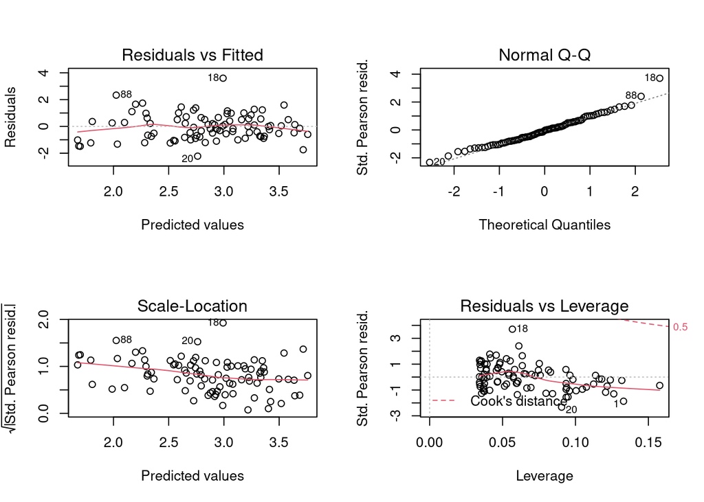

```r
par(mfrow = c(2,2))
plot(m1)
```

```r
par(mfrow = c(1,1))
```

## Moving on to the actual analysis

```r
anova(m1, test = 'Chi')
```

```
## Analysis of Deviance Table
##
## Model: poisson, link: log
##
## Response: spp_num
##
## Terms added sequentially (first to last)
##
##
##            Df Deviance Resid. Df Resid. Dev  Pr(>Chi)
## NULL                          89     452.35
## ph          2   187.23        87     265.12 < 2.2e-16 ***
## biomass     1   165.88        86      99.24 < 2.2e-16 ***
## ph:biomass  2    16.04        84      83.20 0.0003288 ***
## ---
## Signif. codes:  0 '***' 0.001 '**' 0.01 '*' 0.05 '.' 0.1 ' ' 1
```

Since all terms seem to be statistically significant (including the interaction) seems like this model is a good candidate when it comes to its explanatory terms.

I’ll do a `drop1` call just for the fun of it though :)

```r
drop1(m1, test = 'Chi')  # Remember to use Chi when comparing models!
```

```
## Single term deletions
##
## Model:
## spp_num ~ ph * biomass
##            Df Deviance    AIC   LRT  Pr(>Chi)
## <none>          83.201 514.39
## ph:biomass  2   99.242 526.43 16.04 0.0003288 ***
## ---
## Signif. codes:  0 '***' 0.001 '**' 0.01 '*' 0.05 '.' 0.1 ' ' 1
```

As the ANOVA above suggested, removing any term leads to a decrease in the model’s explanatory power (a statistically significant one too!) and thus we stick to the “full” model.

### Checking for overdispersion

GLMs (?) have an important assumption: they assume the deviance to the residual degrees of freedom ration to be 1. If this ratio is significantly larger than 1 then we say the model is overdispersed.

Here’s how I’d check for overdispersion.

```r
m1$deviance / m1$df.residual  # close enough to 1! No need to use quasi family
```

```
## [1] 0.9904898
```

### Plotting and interpreting the model coefs

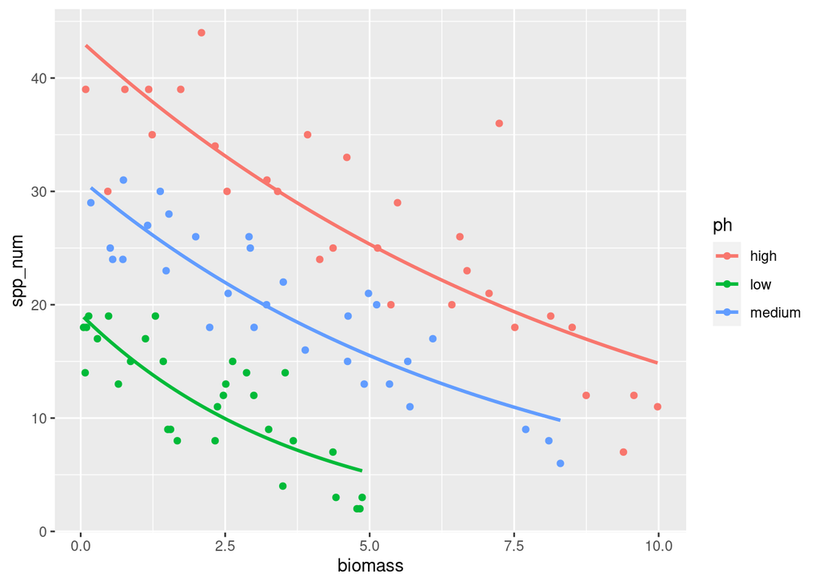

```r
spp_richness %>%
  ggplot(aes(x = biomass, y = spp_num, group = ph, color = ph)) +
  geom_point() +
  stat_smooth(method = 'glm', method.args = list(family = 'poisson'), se = F)
```

And now for the model coefficients:

```r
summary(m1)
```

```
##
## Call:
## glm(formula = spp_num ~ ph * biomass, family = poisson, data = spp_richness)
##
## Deviance Residuals:
##     Min       1Q   Median       3Q      Max
## -2.4978  -0.7485  -0.0402   0.5575   3.2297
##
## Coefficients:
##                  Estimate Std. Error z value Pr(>|z|)
## (Intercept)       3.76812    0.06153  61.240  < 2e-16 ***
## phlow            -0.81557    0.10284  -7.931 2.18e-15 ***
## phmedium         -0.33146    0.09217  -3.596 0.000323 ***
## biomass          -0.10713    0.01249  -8.577  < 2e-16 ***
## phlow:biomass    -0.15503    0.04003  -3.873 0.000108 ***
## phmedium:biomass -0.03189    0.02308  -1.382 0.166954
## ---
## Signif. codes:  0 '***' 0.001 '**' 0.01 '*' 0.05 '.' 0.1 ' ' 1
##
## (Dispersion parameter for poisson family taken to be 1)
##
##     Null deviance: 452.346  on 89  degrees of freedom
## Residual deviance:  83.201  on 84  degrees of freedom
## AIC: 514.39
##
## Number of Fisher Scoring iterations: 4
```

The coefficients above are still in log form, to put in the same scale as the data you can do the following:

```r
m1$family$linkinv(coef(m1)[1])  # this back transforms the intercept
```

```
## (Intercept)
##    43.29874
```

```r
exp(coef(m1)[1])  # this another way of back transforming the intercept
```

```
## (Intercept)
##    43.29874
```

```r
exp(coef(m1)[2]) * exp(coef(m1)[1])  # this does it for low pH
```

```
##    phlow
## 19.15478
```

```r
m1$family$linkinv(coef(m1)[1] + coef(m1)[2])  # also for low pH
```

```
## (Intercept)
##    19.15478
```

The “slope” coefficients describe multiplicative changes in the response variable (eg, changing one unit in the explanatory variable results in a change of the current value times the coefficient)

## Questions I’d like to discuss:

- do you have a rule of thumb for determining whether something is overdispersed or not?
- what’s the difference between log transforming your counts and using a glm? I suppose the question here is what’s the different between using link functions and transforming your data?
- Is it true that you can’t interpret results from transformed data on the “natural scale” (i.e., the relationship between the variables only makes sense if you use the transformed values)